# Thresh-task macBP gamma & odor-condition spectrograms

### 6.2 Participants with a detectable gamma peak, per epoch × condition

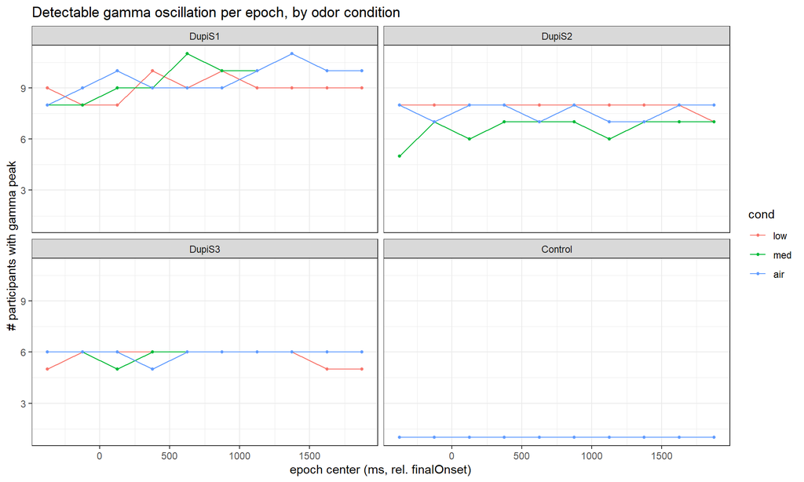

### 6.3 Channel-centered gamma peak frequency across epochs

Group average per condition (bold) with individual sessions as lighter connected dots.

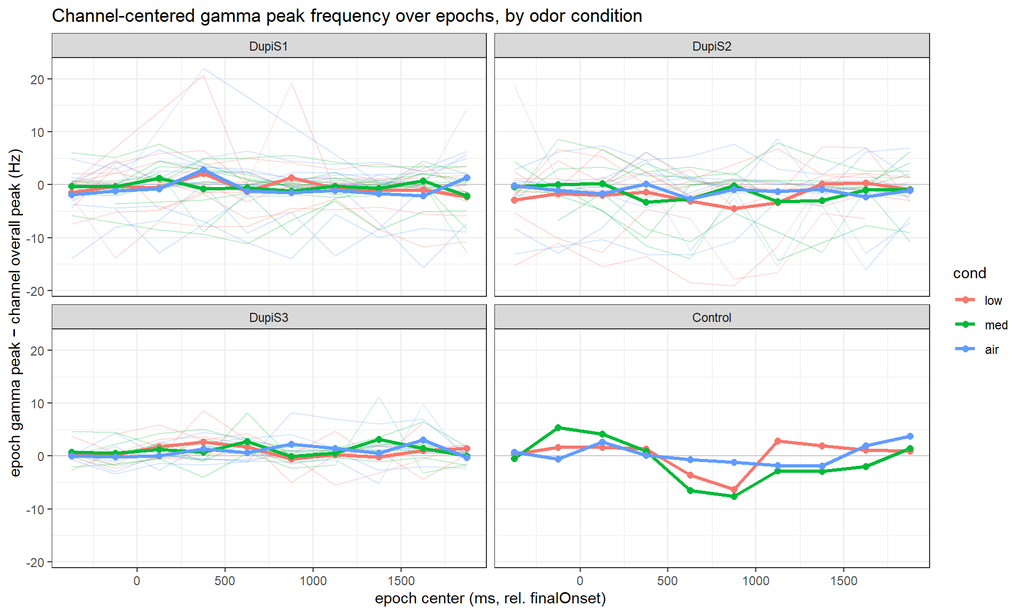

### 6.4 Does gamma peak frequency change over epochs / condition? (LME per group)

Linear mixed-effects model `gammaPeakFreq ~ epoch * cond + (1|subject)`, fit within each group; falls back to `~ epoch + cond` if the interaction model is singular or fails. Epochs with no FOOOF-detected gamma peak are treated as missing. The `epoch` slope is Hz per 250 ms window; `cond` terms are Hz offsets from the `low` reference condition.

LME: gamma peak frequency ~ epoch * cond + (1|subject), per group.

| group | n_obs | n_subj | model | epoch_slope | p_epoch |
| --- | --- | --- | --- | --- | --- |
| DupiS1 | 281 | 11 | epoch*cond | -0.1480 | 0.2454 |
| DupiS2 | 221 | 8 | epoch*cond | 0.1532 | 0.3031 |
| DupiS3 | 175 | 6 | epoch*cond | -0.0517 | 0.6514 |
| Control | 30 | 1 | NA | NA | NA |